# Aprendizaje no supervisado: Trade&Ahead

**Puntos: 60**

## Planteamiento del problema

### Contexto

El mercado de valores ha demostrado constantemente ser un buen lugar para invertir y ahorrar para el futuro. Hay muchas razones convincentes para invertir en acciones. Puede ayudar a combatir la inflación, crear riqueza y también proporciona algunos beneficios fiscales. Los buenos rendimientos constantes de las inversiones durante un largo período de tiempo también pueden crecer mucho más de lo que parece posible. Además, gracias al poder del interés compuesto, cuanto antes se empieza a invertir, mayor es el corpus que se puede tener para la jubilación. En general, invertir en acciones puede ayudar a cumplir las aspiraciones financieras de la vida.

Es importante mantener una cartera diversificada al invertir en acciones para maximizar las ganancias bajo cualquier condición de mercado. Tener una cartera diversificada tiende a generar mayores rendimientos y enfrentar un menor riesgo al moderar las pérdidas potenciales cuando el mercado está a la baja. A menudo es fácil perderse en un mar de métricas financieras para analizar mientras se determina el valor de una acción, y hacer lo mismo para una multitud de acciones para identificar las opciones correctas para un individuo puede ser una tarea tediosa. Al hacer un análisis de conglomerados, se pueden identificar las acciones que exhiben características similares y las que exhiben una correlación mínima. Esto ayudará a los inversores a analizar mejor las acciones en diferentes segmentos del mercado y ayudará a protegerse contra los riesgos que podrían hacer que la cartera sea vulnerable a pérdidas.

### Objetivo

Trade&Ahead es una firma de consultoría financiera que brinda a sus clientes estrategias de inversión personalizadas. Lo contrataron como científico de datos y le proporcionaron datos que incluyen el precio de las acciones y algunos indicadores financieros para algunas empresas que cotizan en la Bolsa de Valores de Nueva York. Le han asignado las tareas de analizar los datos, agrupar las acciones en función de los atributos proporcionados y compartir información sobre las características de cada grupo.

### Diccionario de datos

- Ticker Symbol: una abreviatura utilizada para identificar de forma única las acciones que cotizan en bolsa de una acción en particular en un mercado de valores en particular
- Company: Nombre de la empresa
- GICS Sector: El sector económico específico asignado a una empresa por el Estándar de Clasificación de la Industria Global (GICS) que mejor define sus operaciones comerciales
- GICS Sub Industry: el grupo de subindustria específico asignado a una empresa por el Estándar de Clasificación de la Industria Global (GICS) que mejor define sus operaciones comerciales
- Current Price: Precio actual de la acción en dólares
- Price Change: cambio porcentual en el precio de las acciones en 13 semanas
- Volatility: Desviación estándar del precio de las acciones en las últimas 13 semanas
- ROE: una medida del rendimiento financiero que se calcula dividiendo los ingresos netos por el patrimonio de los accionistas (el patrimonio de los accionistas es igual a los activos de una empresa menos su deuda)
- Cash Ratio: La relación entre las reservas totales de efectivo y equivalentes de efectivo de una empresa y sus pasivos corrientes totales.
- Net Cash Flow: La diferencia entre las entradas y salidas de caja de una empresa (en dólares)
- Net Income: Ingresos menos gastos, intereses e impuestos (en dólares)
- Earnings Per Share: la utilidad neta de la empresa dividida por el número de acciones ordinarias que tiene en circulación (en dólares)
- Estimated Shares Outstanding: Acciones de la Compañía actualmente en poder de todos sus accionistas
- P/E Ratio: relación entre el precio actual de las acciones de la empresa y las ganancias por acción
- P/B Ratio: relación entre el precio de las acciones de la empresa por acción y su valor en libros por acción (el valor en libros de una empresa es la diferencia neta entre los activos totales y los pasivos totales de esa empresa)

## Importación de bibliotecas necesarias

```python
%pip install seaborn
```

[output not shown]

```python
%pip install yellowbrick
```

[output not shown]

```python
%pip install setuptools
```

```python
# Libraries to help with reading and manipulating data
import numpy as np
import pandas as pd

# Libraries to help with data visualization
import matplotlib.pyplot as plt
import seaborn as sns

# Removes the limit for the number of displayed columns
pd.set_option("display.max_columns", None)
# Sets the limit for the number of displayed rows
pd.set_option("display.max_rows", 200)

# to scale the data using z-score
from sklearn.preprocessing import StandardScaler

# to perform PCA
from sklearn.decomposition import PCA

# to compute distances
from scipy.spatial.distance import cdist, pdist

# to perform k-means clustering and compute silhouette scores
from sklearn.cluster import KMeans
from sklearn.metrics import silhouette_score

# to visualize the elbow curve and silhouette scores
from yellowbrick.cluster import KElbowVisualizer, SilhouetteVisualizer

# to perform hierarchical clustering, compute cophenetic correlation, and create dendrograms
from sklearn.cluster import AgglomerativeClustering
from scipy.cluster.hierarchy import dendrogram, linkage, cophenet

# to suppress warnings
import warnings
warnings.filterwarnings("ignore")
```

## Cargando el conjunto de datos

```python
## Complete the code to import the data
data = pd.read_csv('stock_data.csv')
```

## Descripción general del conjunto de datos

Los pasos iniciales para obtener una visión general de cualquier conjunto de datos son:

- observe las primeras filas del conjunto de datos, para verificar si el conjunto de datos se ha cargado correctamente o no,
- obtenga información sobre el número de filas y columnas en el conjunto de datos,
- averigüe los tipos de datos de las columnas para garantizar que los datos se almacenen en el formato preferido y que el valor de cada propiedad sea el esperado,
- verifique el resumen estadístico del conjunto de datos para obtener una descripción general de las columnas numéricas de los datos.

### Comprobando la forma del conjunto de datos

```python
data.shape
```

```
(340, 15)
```

```python
# checking shape of the data
print(f"There are {'340'} rows and {'15'} columns.") ## Complete the code to get the shape of data
```

```
There are 340 rows and 15 columns.
```

### Mostrando algunas filas del conjunto de datos

```python
# let's view a sample of the data
data.sample(n=10, random_state=1)
```

|  | Ticker Symbol | Security | GICS Sector | GICS Sub Industry | Current Price | Price Change | Volatility | ROE | Cash Ratio | Net Cash Flow | Net Income | Earnings Per Share | Estimated Shares Outstanding | P/E Ratio | P/B Ratio |
| --- | --- | --- | --- | --- | --- | --- | --- | --- | --- | --- | --- | --- | --- | --- | --- |
| 102 | DVN | Devon Energy Corp. | Energy | Oil & Gas Exploration & Production | 32.000000 | -15.478079 | 2.923698 | 205 | 70 | 830000000 | -14454000000 | -35.55 | 4.065823e+08 | 93.089287 | 1.785616 |
| 125 | FB | Facebook | Information Technology | Internet Software & Services | 104.660004 | 16.224320 | 1.320606 | 8 | 958 | 592000000 | 3669000000 | 1.31 | 2.800763e+09 | 79.893133 | 5.884467 |
| 11 | AIV | Apartment Investment & Mgmt | Real Estate | REITs | 40.029999 | 7.578608 | 1.163334 | 15 | 47 | 21818000 | 248710000 | 1.52 | 1.636250e+08 | 26.335526 | -1.269332 |
| 248 | PG | Procter & Gamble | Consumer Staples | Personal Products | 79.410004 | 10.660538 | 0.806056 | 17 | 129 | 160383000 | 636056000 | 3.28 | 4.913916e+08 | 24.070121 | -2.256747 |
| 238 | OXY | Occidental Petroleum | Energy | Oil & Gas Exploration & Production | 67.610001 | 0.865287 | 1.589520 | 32 | 64 | -588000000 | -7829000000 | -10.23 | 7.652981e+08 | 93.089287 | 3.345102 |
| 336 | YUM | Yum! Brands Inc | Consumer Discretionary | Restaurants | 52.516175 | -8.698917 | 1.478877 | 142 | 27 | 159000000 | 1293000000 | 2.97 | 4.353535e+08 | 17.682214 | -3.838260 |
| 112 | EQT | EQT Corporation | Energy | Oil & Gas Exploration & Production | 52.130001 | -21.253771 | 2.364883 | 2 | 201 | 523803000 | 85171000 | 0.56 | 1.520911e+08 | 93.089287 | 9.567952 |
| 147 | HAL | Halliburton Co. | Energy | Oil & Gas Equipment & Services | 34.040001 | -5.101751 | 1.966062 | 4 | 189 | 7786000000 | -671000000 | -0.79 | 8.493671e+08 | 93.089287 | 17.345857 |
| 89 | DFS | Discover Financial Services | Financials | Consumer Finance | 53.619999 | 3.653584 | 1.159897 | 20 | 99 | 2288000000 | 2297000000 | 5.14 | 4.468872e+08 | 10.431906 | -0.375934 |
| 173 | IVZ | Invesco Ltd. | Financials | Asset Management & Custody Banks | 33.480000 | 7.067477 | 1.580839 | 12 | 67 | 412000000 | 968100000 | 2.26 | 4.283628e+08 | 14.814159 | 4.218620 |

### Comprobación de los tipos de datos de las columnas para el conjunto de datos

```python
# checking the column names and datatypes
data.info()
```

```
<class 'pandas.core.frame.DataFrame'>
RangeIndex: 340 entries, 0 to 339
Data columns (total 15 columns):
 #   Column                        Non-Null Count  Dtype
---  ------                        --------------  -----
 0   Ticker Symbol                 340 non-null    object
 1   Security                      340 non-null    object
 2   GICS Sector                   340 non-null    object
 3   GICS Sub Industry             340 non-null    object
 4   Current Price                 340 non-null    float64
 5   Price Change                  340 non-null    float64
 6   Volatility                    340 non-null    float64
 7   ROE                           340 non-null    int64
 8   Cash Ratio                    340 non-null    int64
 9   Net Cash Flow                 340 non-null    int64
 10  Net Income                    340 non-null    int64
 11  Earnings Per Share            340 non-null    float64
 12  Estimated Shares Outstanding  340 non-null    float64
 13  P/E Ratio                     340 non-null    float64
 14  P/B Ratio                     340 non-null    float64
dtypes: float64(7), int64(4), object(4)
memory usage: 40.0+ KB
```

### Creación de una copia de los datos originales

```python
# copying the data to another variable to avoid any changes to original data
df = data.copy()
```

### Comprobación de duplicados y valores faltantes

```python
# checking for duplicate values
df.duplicated().sum() ## Complete the code to get total number of duplicate values
```

```
np.int64(0)
```

El conjunto de datos no tiene valores faltantes ni duplicados. Todas las columnas con objeto dtype deben ser de categoría dtype para conservar memoria

```python
# checking for missing values in the data
df.isnull().sum() ## Complete the code to check the missing values in the data
```

```
Ticker Symbol                   0
Security                        0
GICS Sector                     0
GICS Sub Industry               0
Current Price                   0
Price Change                    0
Volatility                      0
ROE                             0
Cash Ratio                      0
Net Cash Flow                   0
Net Income                      0
Earnings Per Share              0
Estimated Shares Outstanding    0
P/E Ratio                       0
P/B Ratio                       0
dtype: int64
```

### Resumen estadístico del conjunto de datos

**Veamos el resumen estadístico de los datos.**

```python
df.describe(include='all').T
```

|  | count | unique | top | freq | mean | std | min | 25% | 50% | 75% | max |
| --- | --- | --- | --- | --- | --- | --- | --- | --- | --- | --- | --- |
| Ticker Symbol | 340 | 340 | AAL | 1 | NaN | NaN | NaN | NaN | NaN | NaN | NaN |
| Security | 340 | 340 | American Airlines Group | 1 | NaN | NaN | NaN | NaN | NaN | NaN | NaN |
| GICS Sector | 340 | 11 | Industrials | 53 | NaN | NaN | NaN | NaN | NaN | NaN | NaN |
| GICS Sub Industry | 340 | 104 | Oil & Gas Exploration & Production | 16 | NaN | NaN | NaN | NaN | NaN | NaN | NaN |
| Current Price | 340.0 | NaN | NaN | NaN | 80.862345 | 98.055086 | 4.5 | 38.555 | 59.705 | 92.880001 | 1274.949951 |
| Price Change | 340.0 | NaN | NaN | NaN | 4.078194 | 12.006338 | -47.129693 | -0.939484 | 4.819505 | 10.695493 | 55.051683 |
| Volatility | 340.0 | NaN | NaN | NaN | 1.525976 | 0.591798 | 0.733163 | 1.134878 | 1.385593 | 1.695549 | 4.580042 |
| ROE | 340.0 | NaN | NaN | NaN | 39.597059 | 96.547538 | 1.0 | 9.75 | 15.0 | 27.0 | 917.0 |
| Cash Ratio | 340.0 | NaN | NaN | NaN | 70.023529 | 90.421331 | 0.0 | 18.0 | 47.0 | 99.0 | 958.0 |
| Net Cash Flow | 340.0 | NaN | NaN | NaN | 55537620.588235 | 1946365312.175789 | -11208000000.0 | -193906500.0 | 2098000.0 | 169810750.0 | 20764000000.0 |
| Net Income | 340.0 | NaN | NaN | NaN | 1494384602.941176 | 3940150279.327936 | -23528000000.0 | 352301250.0 | 707336000.0 | 1899000000.0 | 24442000000.0 |
| Earnings Per Share | 340.0 | NaN | NaN | NaN | 2.776662 | 6.587779 | -61.2 | 1.5575 | 2.895 | 4.62 | 50.09 |
| Estimated Shares Outstanding | 340.0 | NaN | NaN | NaN | 577028337.75403 | 845849595.417695 | 27672156.86 | 158848216.1 | 309675137.8 | 573117457.325 | 6159292035.0 |
| P/E Ratio | 340.0 | NaN | NaN | NaN | 32.612563 | 44.348731 | 2.935451 | 15.044653 | 20.819876 | 31.764755 | 528.039074 |
| P/B Ratio | 340.0 | NaN | NaN | NaN | -1.718249 | 13.966912 | -76.119077 | -4.352056 | -1.06717 | 3.917066 | 129.064585 |

## Análisis exploratorio de datos

### Análisis univariado

```python
# function to plot a boxplot and a histogram along the same scale.


def histogram_boxplot(df, feature, figsize=(12, 7), kde=False, bins=None):
    """
    Boxplot and histogram combined

    data: dataframe
    feature: dataframe column
    figsize: size of figure (default (12,7))
    kde: whether to the show density curve (default False)
    bins: number of bins for histogram (default None)
    """
    f2, (ax_box2, ax_hist2) = plt.subplots(
        nrows=2,  # Number of rows of the subplot grid= 2
        sharex=True,  # x-axis will be shared among all subplots
        gridspec_kw={"height_ratios": (0.25, 0.75)},
        figsize=figsize,
    )  # creating the 2 subplots
    sns.boxplot(
        data=df, x=feature, ax=ax_box2, showmeans=True, color="violet"
    )  # boxplot will be created and a star will indicate the mean value of the column
    sns.histplot(
        data=df, x=feature, kde=kde, ax=ax_hist2, bins=bins, palette="winter"
    ) if bins else sns.histplot(
        data=df, x=feature, kde=kde, ax=ax_hist2
    )  # For histogram
    ax_hist2.axvline(
        df[feature].mean(), color="green", linestyle="--"
    )  # Add mean to the histogram
    ax_hist2.axvline(
        df[feature].median(), color="black", linestyle="-"
    )  # Add median to the histogram
```

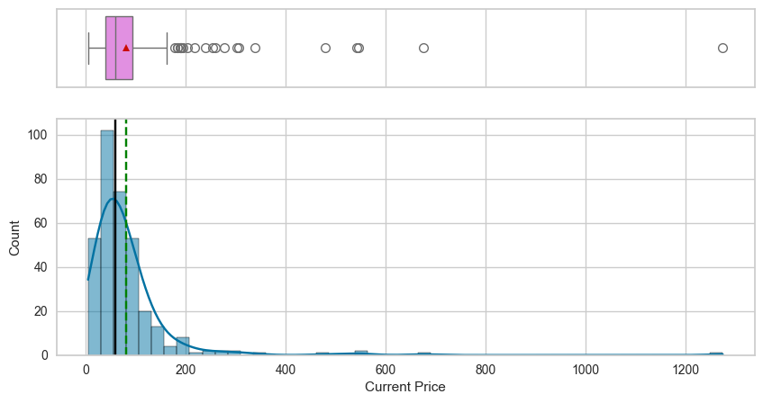

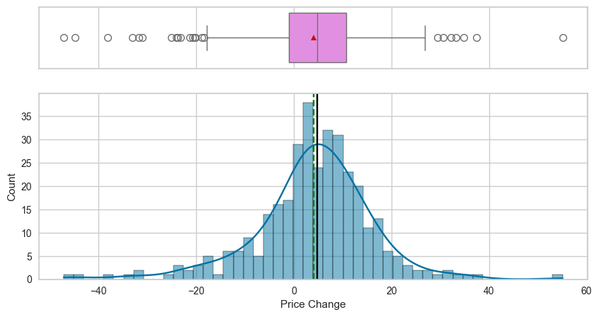

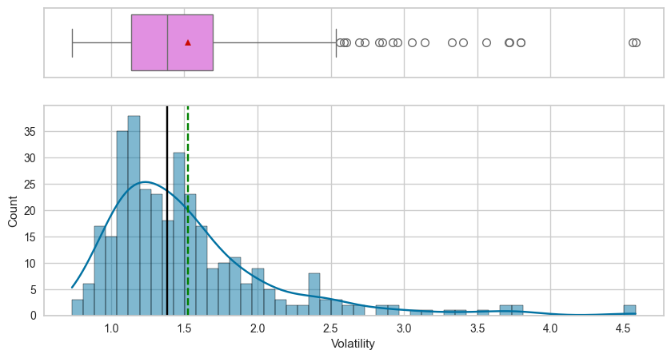

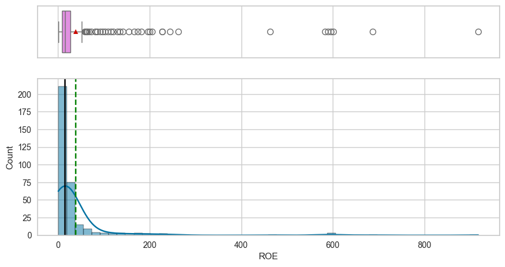

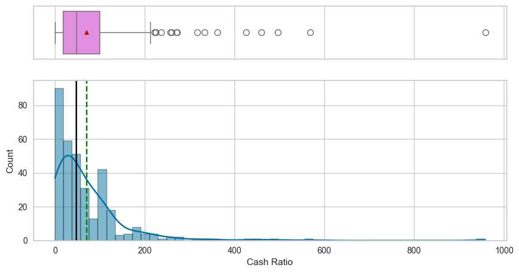

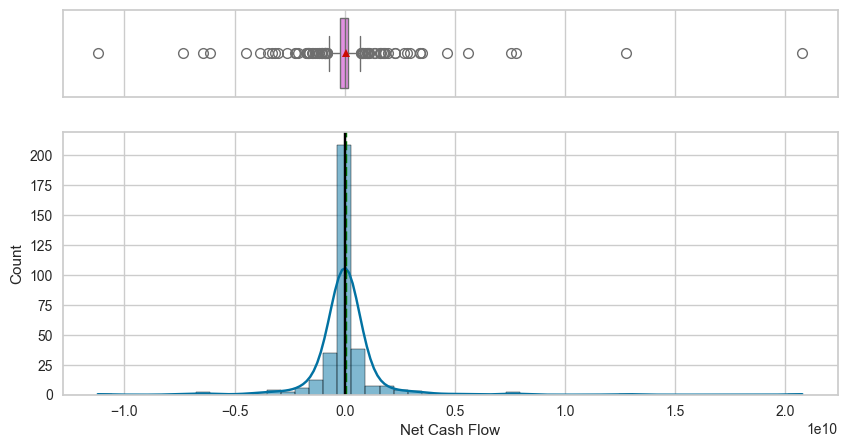

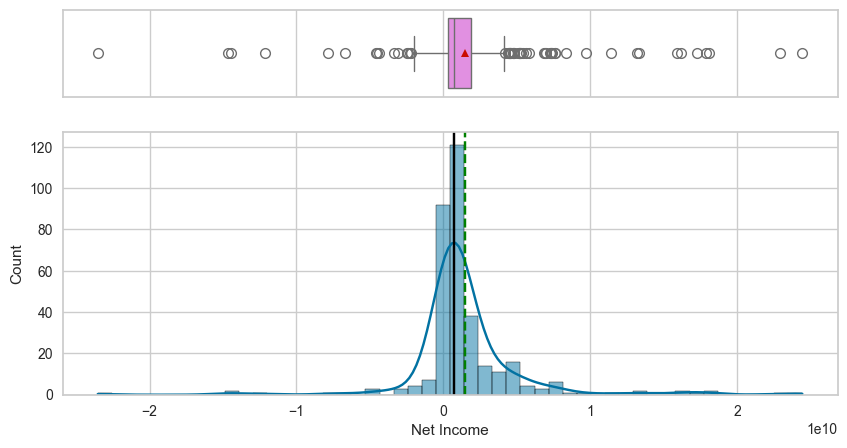

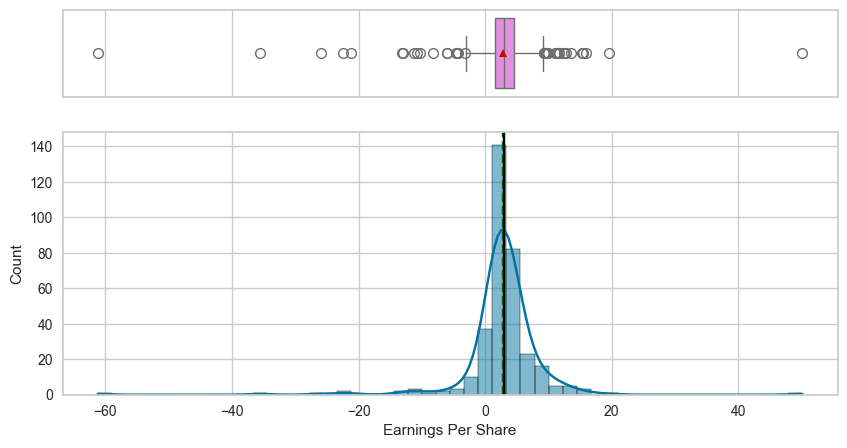

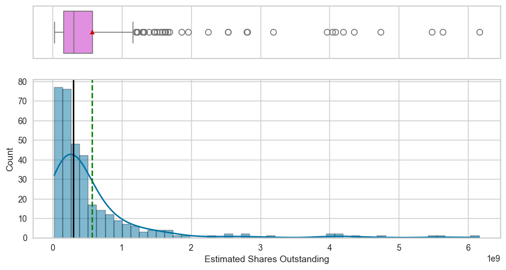

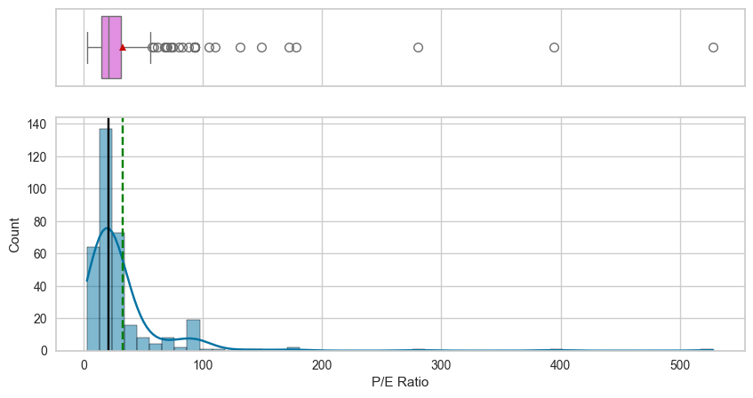

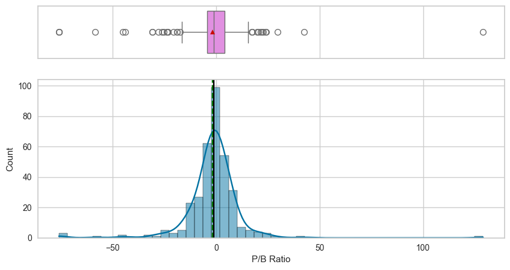

```python
# selecting numerical columns
num_cols = df.select_dtypes(include=np.number).columns.tolist()

for item in num_cols:
    histogram_boxplot(df, item, bins=50, kde=True, figsize=(10, 5))
```

**`Current Price`**

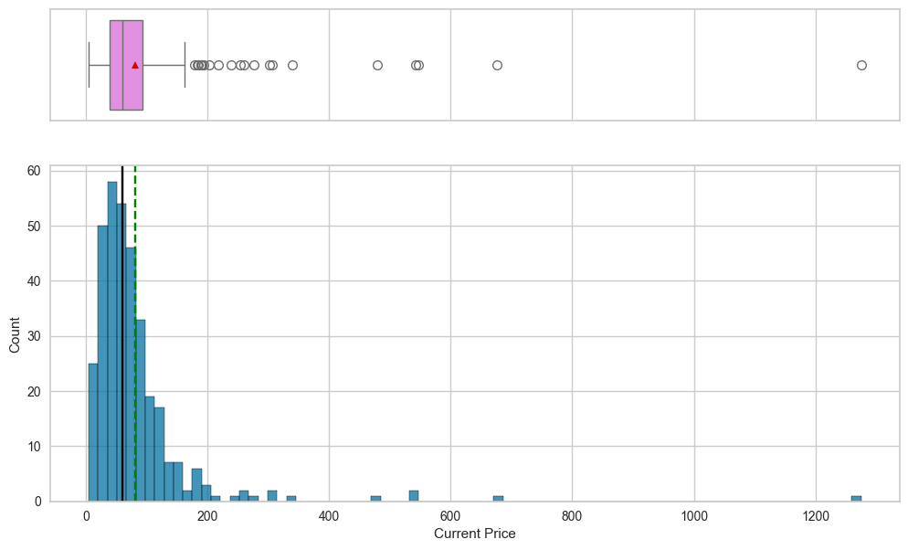

```python
histogram_boxplot(df, 'Current Price')
```

**`Price Change`**

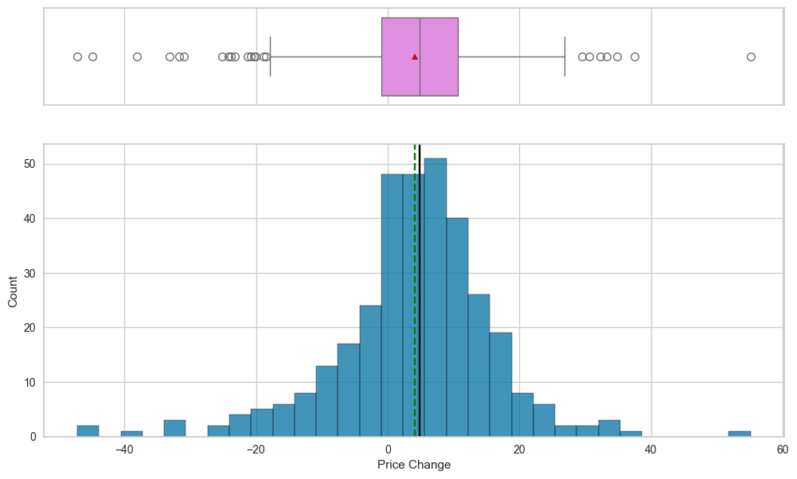

```python
histogram_boxplot(df,'Price Change')  ## Complete the code to create histogram_boxplot for 'Price Change'
```

**`Volatility`**

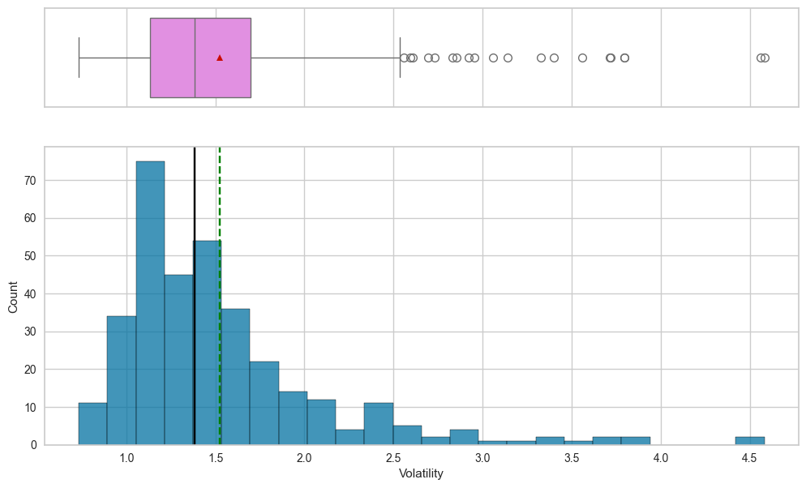

```python
histogram_boxplot(df,'Volatility')  ## Complete the code to create histogram_boxplot for 'Volatility'
```

**`ROE`**

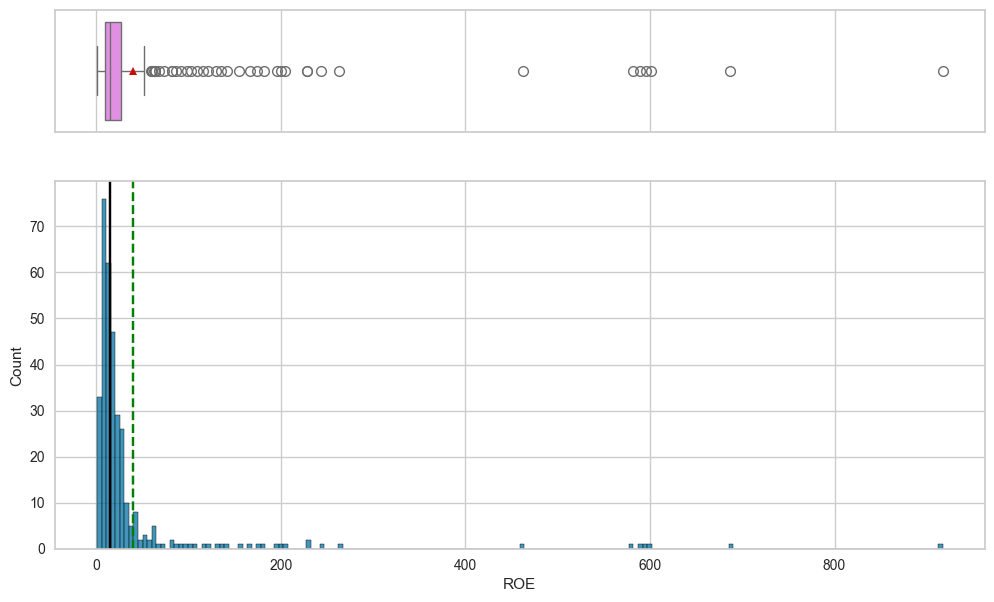

```python
histogram_boxplot(df,'ROE')  ## Complete the code to create histogram_boxplot for 'ROE'
```

**`Cash Ratio`**

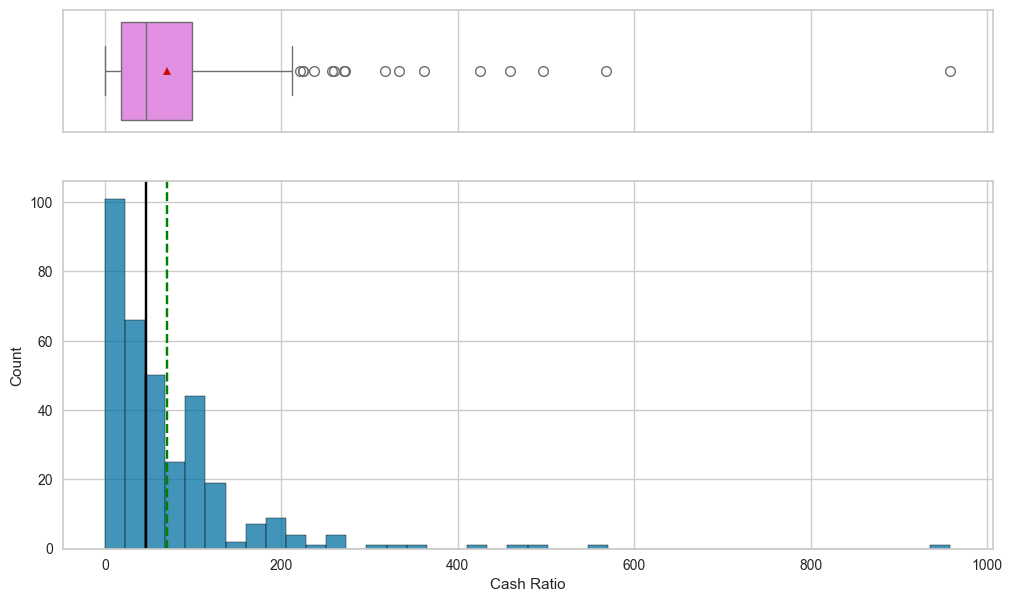

```python
histogram_boxplot(df,'Cash Ratio')  ## Complete the code to create histogram_boxplot for 'Cash Ratio'
```

**`Net Cash Flow`**

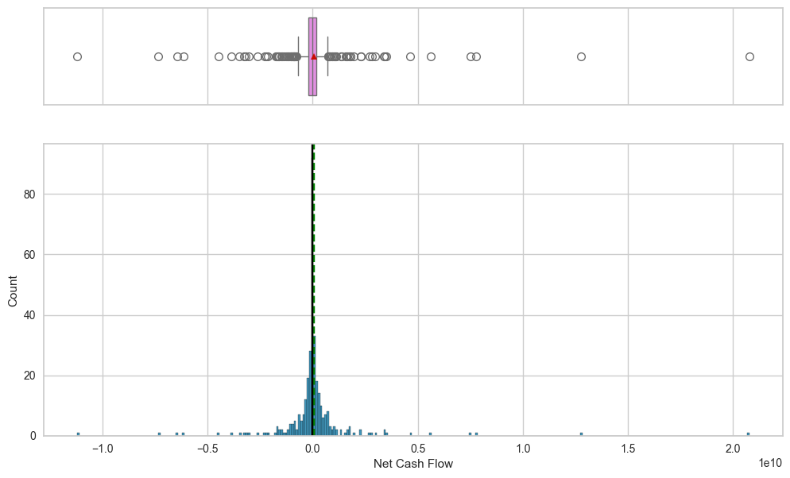

```python
histogram_boxplot(df,'Net Cash Flow')  ## Complete the code to create histogram_boxplot for 'Net Cash Flow'
```

**`Net Income`**

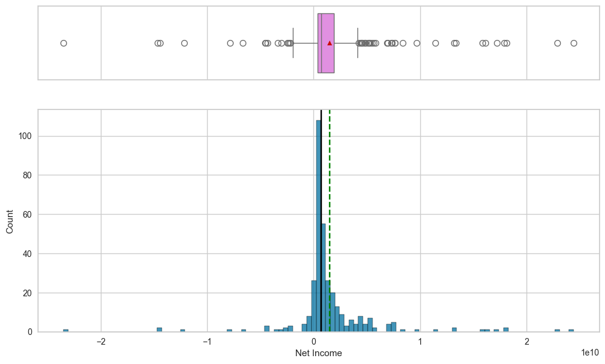

```python
histogram_boxplot(df,'Net Income')  ## Complete the code to create histogram_boxplot for 'Net Income'
```

**`Earnings Per Share`**

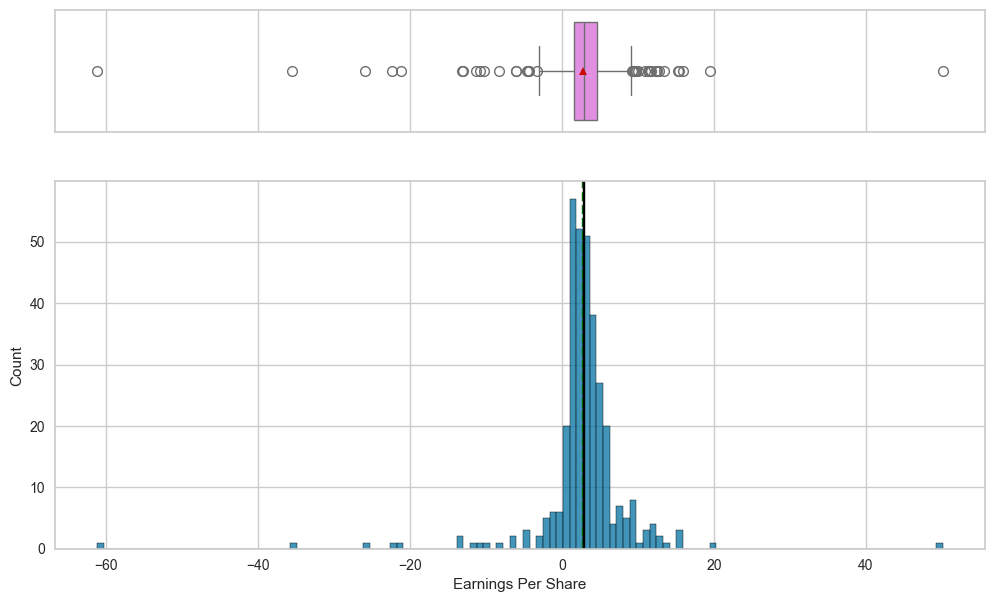

```python
histogram_boxplot(df,'Earnings Per Share')  ## Complete the code to create histogram_boxplot for 'Earnings Per Share'
```

**`Estimated Shares Outstanding`**

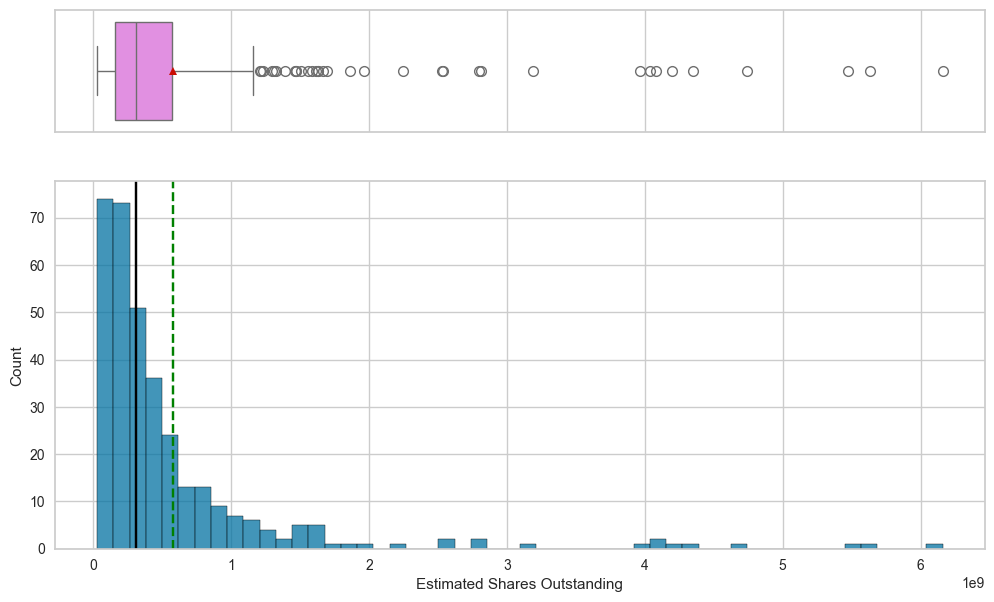

```python
histogram_boxplot(df,'Estimated Shares Outstanding')  ## Complete the code to create histogram_boxplot for 'Estimated Shares Outstanding'
```

**`P/E Ratio`**

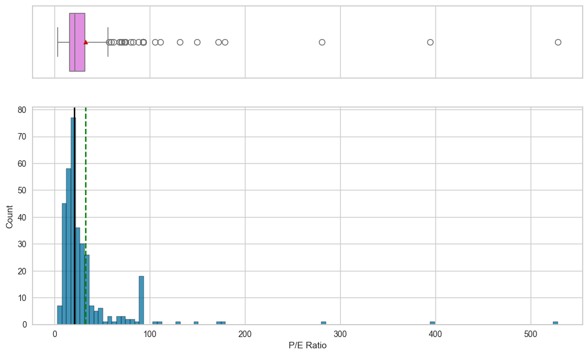

```python
histogram_boxplot(df,'P/E Ratio')  ## Complete the code to create histogram_boxplot for 'P/E Ratio'
```

**`P/B Ratio`**

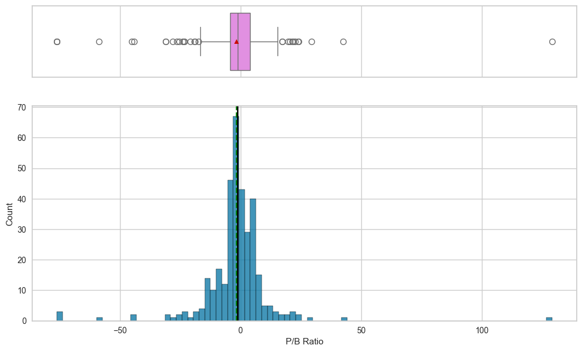

```python
histogram_boxplot(df,'P/B Ratio')  ## Complete the code to create histogram_boxplot for 'P/B Ratio'
```

```python
# function to create labeled barplots


def labeled_barplot(df, feature, perc=False, n=None):
    """
    Barplot with percentage at the top

    data: dataframe
    feature: dataframe column
    perc: whether to display percentages instead of count (default is False)
    n: displays the top n category levels (default is None, i.e., display all levels)
    """

    total = len(df[feature])  # length of the column
    count = df[feature].nunique()
    if n is None:
        plt.figure(figsize=(count + 1, 5))
    else:
        plt.figure(figsize=(n + 1, 5))

    plt.xticks(rotation=90, fontsize=15)
    ax = sns.countplot(
        data=df,
        x=feature,
        palette="Paired",
        order=df[feature].value_counts().index[:n].sort_values(),
    )

    for p in ax.patches:
        if perc == True:
            label = "{:.1f}%".format(
                100 * p.get_height() / total
            )  # percentage of each class of the category
        else:
            label = p.get_height()  # count of each level of the category

        x = p.get_x() + p.get_width() / 2  # width of the plot
        y = p.get_height()  # height of the plot

        ax.annotate(
            label,
            (x, y),
            ha="center",
            va="center",
            size=12,
            xytext=(0, 5),
            textcoords="offset points",
        )  # annotate the percentage

    plt.show()  # show the plot
```

**`GICS Sector`**

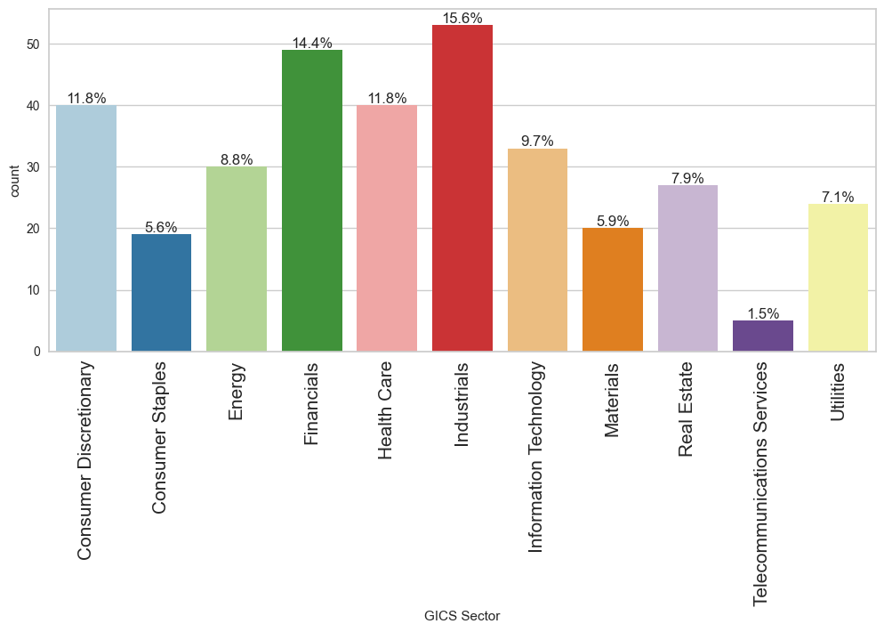

```python
labeled_barplot(df, 'GICS Sector', perc=True)
```

**`GICS Sub Industry`**

[figure not shown]

```python
labeled_barplot(df,'GICS Sub Industry', perc=True)  ## Complete the code to create a labelled barplot for 'GICS Sub Industry'
```

### Análisis bivariado

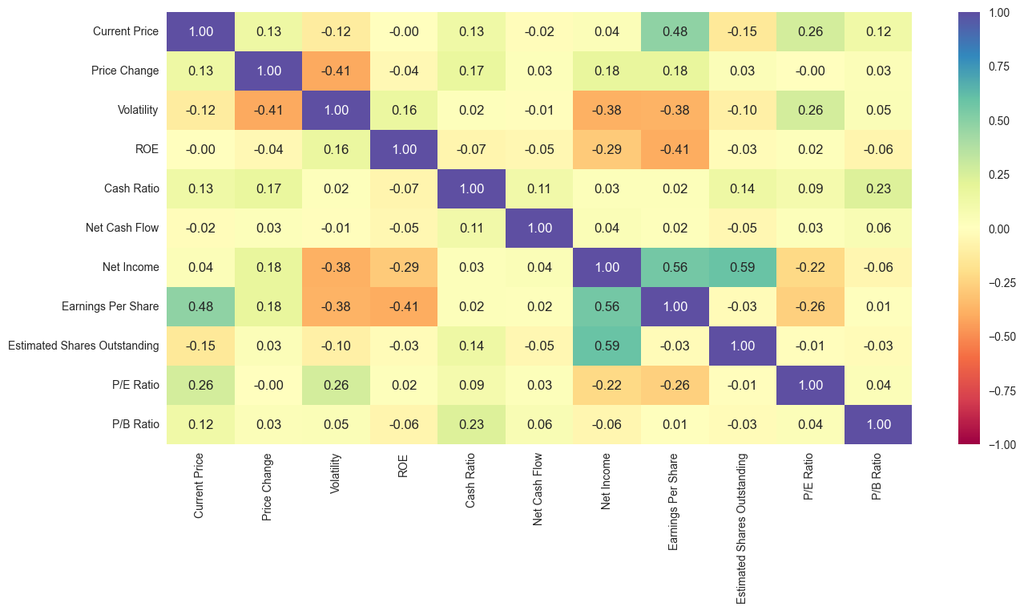

```python
# correlation check
plt.figure(figsize=(15, 7))
sns.heatmap(
    df[num_cols].corr(), annot=True, vmin=-1, vmax=1, fmt=".2f", cmap="Spectral"
)
plt.show()
```

Varias variables están moderadamente correlacionadas (+/- .40) entre sí La volatilidad está correlacionada negativamente con el cambio de precios, es decir, a medida que una acción se vuelve más volátil, es probable que su precio baje. Los ingresos netos tienen una correlación negativa con la volatilidad, es decir, a medida que una empresa genera mayores ingresos netos, es probable que su precio sea menos volátil. Los ingresos netos también están correlacionados positivamente con las ganancias por acción (EPS) y las acciones estimadas en circulación. El EPS está correlacionado positivamente con el precio actual, es decir, a medida que aumenta el EPS de una empresa, es muy probable que sus precios también aumenten. Las EPS también están correlacionadas negativamente con el ROE, es decir, a medida que una empresa genera más capital para los accionistas, una cantidad equivalente de ingresos netos en los siguientes períodos generará un menor rendimiento.

**Veamos las acciones de qué sector económico han visto el máximo aumento de precio en promedio.**

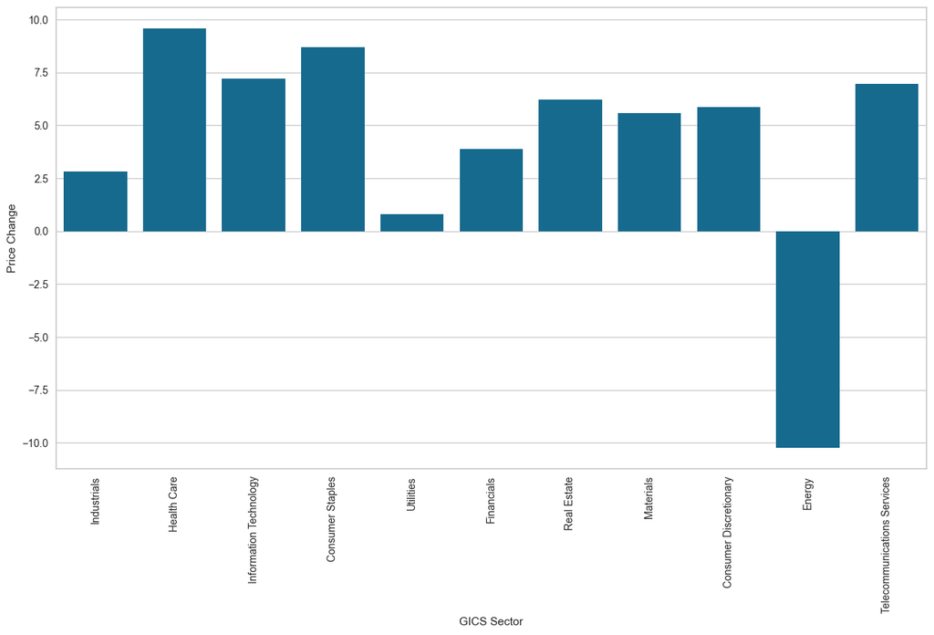

```python
plt.figure(figsize=(15,8))
sns.barplot(data=df, x='GICS Sector', y='Price Change', ci=False)  ## Complete the code to choose the right variables
plt.xticks(rotation=90)
plt.show()
```

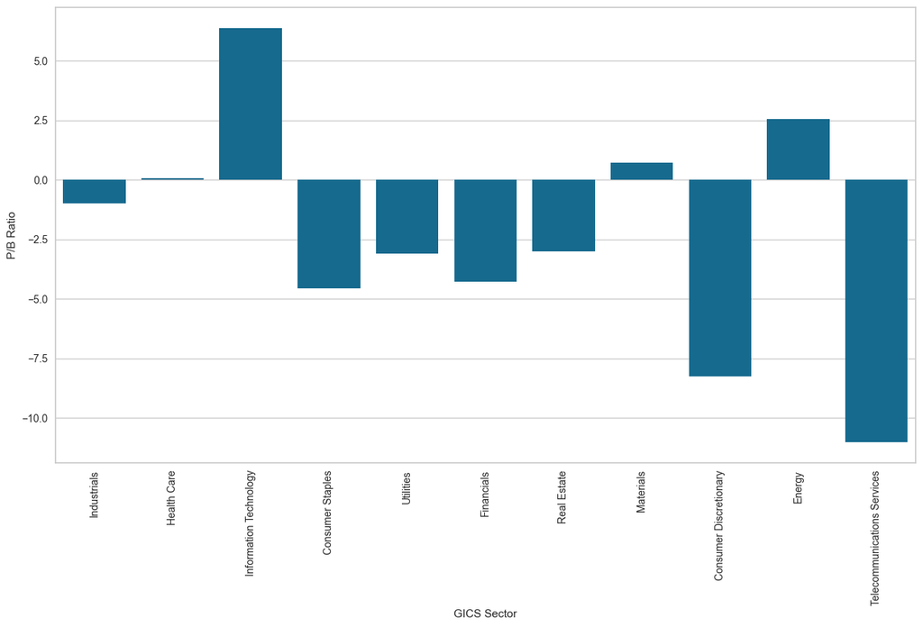

```python
plt.figure(figsize=(15,8))
sns.barplot(data=df, x='GICS Sector', y='P/B Ratio', ci=False)  ## Complete the code to choose the right variables
plt.xticks(rotation=90)
plt.show()
```

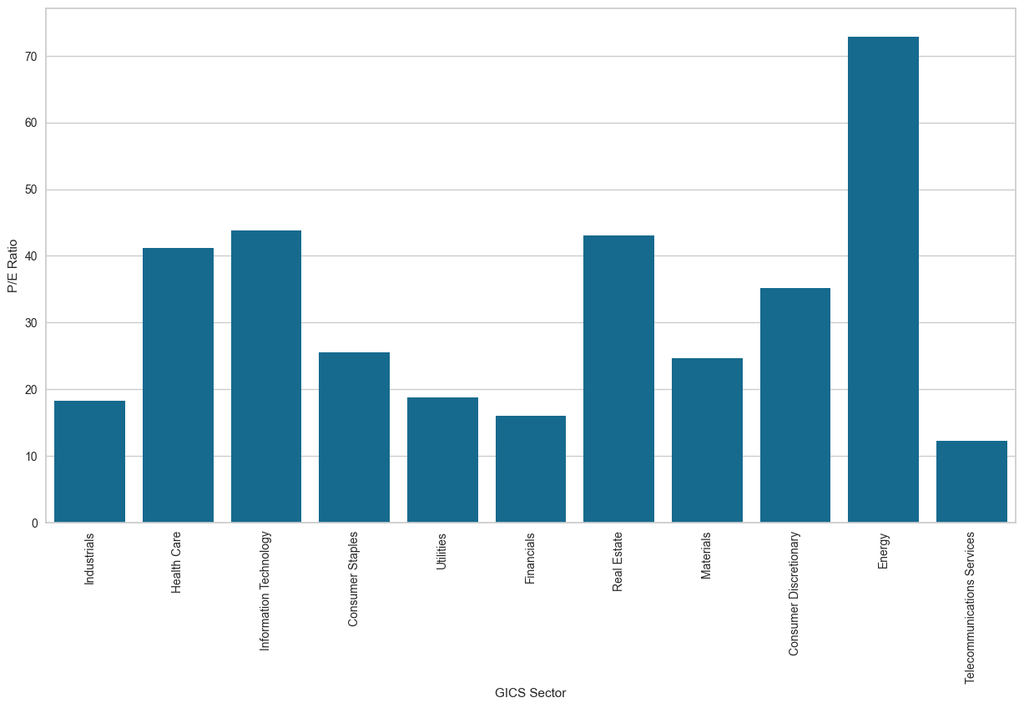

```python
plt.figure(figsize=(15,8))
sns.barplot(data=df, x='GICS Sector', y='P/E Ratio', ci=False)  ## Complete the code to choose the right variables
plt.xticks(rotation=90)
plt.show()
```

**La volatilidad explica la fluctuación en el precio de las acciones. Una acción con alta volatilidad experimentará cambios de precios más bruscos, lo que la convierte en una inversión más riesgosa. Veamos cómo varía la volatilidad, en promedio, entre sectores económicos.**

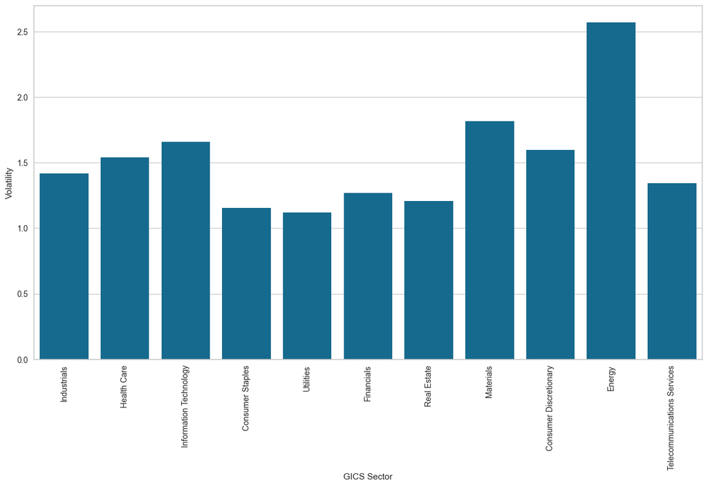

```python
plt.figure(figsize=(15,8))
sns.barplot(data=df, x='GICS Sector', y='Volatility', ci=False)  ## Complete the code to choose the right variables
plt.xticks(rotation=90)
plt.show()
```

## Preprocesamiento de datos

### Comprobación de valores atípicos

- Tracemos los diagramas de caja de todas las columnas numéricas para verificar si hay valores atípicos.

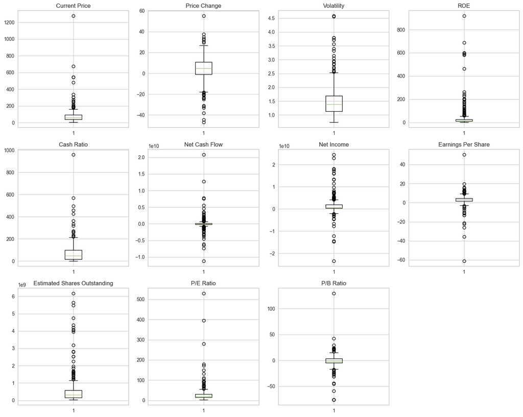

```python
plt.figure(figsize=(15, 12))

numeric_columns = df.select_dtypes(include=np.number).columns.tolist()

for i, variable in enumerate(numeric_columns):
    plt.subplot(3, 4, i + 1)
    plt.boxplot(df[variable], whis=1.5)
    plt.tight_layout()
    plt.title(variable)

plt.show()
```

### Escalado

- Escalemos los datos antes de proceder con la agrupación.

```python
# scaling the data before clustering
scaler = StandardScaler()
subset = df[num_cols].copy()  ## Complete the code to scale the data
subset_scaled = scaler.fit_transform(subset)
```

```python
# creating a dataframe of the scaled data
subset_scaled_df = pd.DataFrame(subset_scaled, columns=subset.columns)
```

## Agrupación K-means

### Comprobación del diagrama de codo

```python
k_means_df = subset_scaled_df.copy()
```

```
Number of Clusters: 1 	Average Distortion: 2.5425069919221697
Number of Clusters: 2 	Average Distortion: 2.3862098789299604
Number of Clusters: 3 	Average Distortion: 2.33620927590848
Number of Clusters: 4 	Average Distortion: 2.2190505638334423
Number of Clusters: 5 	Average Distortion: 2.133404401901685
Number of Clusters: 6 	Average Distortion: 2.0815036860937144
Number of Clusters: 7 	Average Distortion: 2.0045413402786814
Number of Clusters: 8 	Average Distortion: 1.986423782487441
Number of Clusters: 9 	Average Distortion: 1.956222103389025
Number of Clusters: 10 	Average Distortion: 1.9360473996664198
Number of Clusters: 11 	Average Distortion: 1.8615942883461607
Number of Clusters: 12 	Average Distortion: 1.8219574388532505
Number of Clusters: 13 	Average Distortion: 1.7936924742607907
Number of Clusters: 14 	Average Distortion: 1.7567842179093438
```

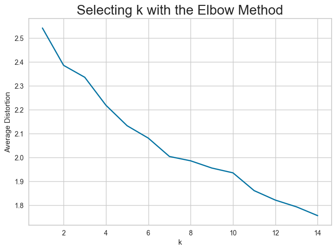

```python
clusters = range(1, 15)
meanDistortions = []

for k in clusters:
    model = KMeans(n_clusters=k, random_state=1)
    model.fit(subset_scaled_df)
    prediction = model.predict(k_means_df)
    distortion = (
        sum(np.min(cdist(k_means_df, model.cluster_centers_, "euclidean"), axis=1))
        / k_means_df.shape[0]
    )

    meanDistortions.append(distortion)

    print("Number of Clusters:", k, "\tAverage Distortion:", distortion)

plt.plot(clusters, meanDistortions, "bx-")
plt.xlabel("k")
plt.ylabel("Average Distortion")
plt.title("Selecting k with the Elbow Method", fontsize=20)
plt.show()
```

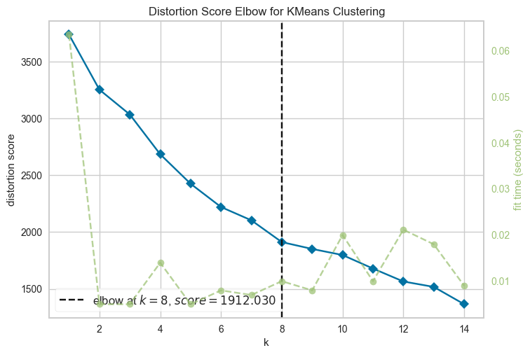

```python
model = KMeans(random_state=1)
visualizer = KElbowVisualizer(model, k=(1, 15), timings=True)
visualizer.fit(k_means_df)  # fit the data to the visualizer
visualizer.show()  # finalize and render figure
```